# Evidence of cryptic and pseudocryptic speciation in the Paracalanus parvus species complex (Crustacea, Copepoda, Calanoida) | Frontiers in Zoology | Full Text

### Phylogeography

**Figure 7**

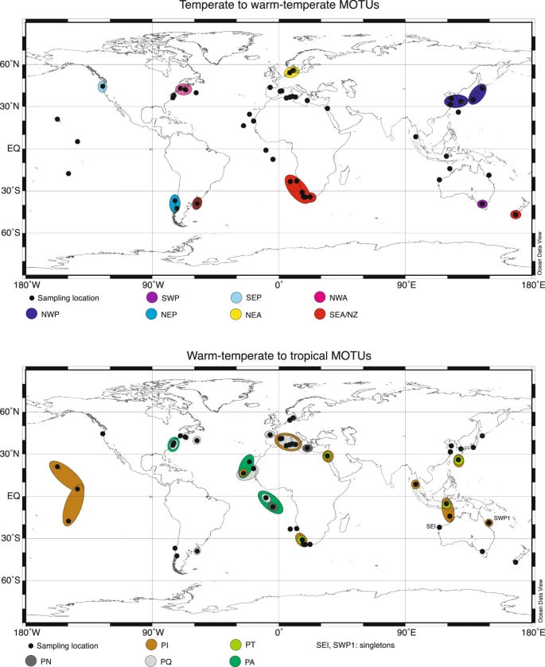

**Overview of sampling locations for specimens of the** *Paracalanus parvus* **complex (for exact information on latitude/longitude etc. see Additional file** **1** **) and geographic distribution of MOTUs**.

[Full size image](https://frontiersinzoology.biomedcentral.com/articles/10.1186/1742-9994-11-19/figures/7)

Two locations for PN were also included in the analyses but we did not search particularly for this species on a global scale and thus its distribution cannot be evaluated here.

## Discussion

This study presents the first step to disentangling the genetic diversity of the ecologically important *Paracalanus parvus* species complex by using mitochondrial genes. Cleary this complex is composed of more MOTUs than morphologically described species and may thus be subject to cryptic and pseudocryptic speciation. The results provide a “global” framework for scientists identify individuals from the *Paracalanus parvus* complex according to their genetic affiliation (MOTU). It can also serve as a basis for future morphological taxonomy to test the validity of the found MOTUs.

### Genetic species delimitation

Independent methods without *a priori* defined groups are used to investigate the Paracalanus parvus complex (ABGD, GMYC, cladistic analyses (ML, BI), classical barcoding, Rosenberg’s P(AB)). These methods are generally congruent. They differ in the way that in some methods clades are subdivided or merged. In classical taxonomy this problem is well known and then nomenclature is helpful. In other words, one author defines two taxa as subspecies while another author defines the same taxa as separate species. It is important to note that the methods do not contradict each other in the subdivision but only in their assignment to hierarchy. Thus, the number of MOTUs varies between 11 and 15 MOTUs but not all of these may represent reproductively isolated species.

The seven MOTUs that are congruent in all analysis have genetic distances between MOTUS greater than 8% and therefore represent putative species. Speciation in marine copepods is assumed to have occurred when sequence divergences are approximately 8 – 9% (e.g. [56, 57]. Some methods separate lineages within the level of intraspecific variety of copepods (1 – 4%, e.g. [56, 58]. This accounts for the MOTUs SEA/NZ and NWA (uncorrected p-distance 3.2 – 4.2%) and for PA and PT (4.8 – 5.7% uncorrected p-distance). These two MOTUs may be recently diverged conspecific lineages, due to their geographic isolation, however, they show evidence of the possible existence of two species which would be in concordance with the unified species concept of [59]. In total, 10 to 12 putative species are found within the present genetic data set of the *Paracalanus parvus* species complex.

For this species complex, COI has provided a rapid and sufficient support for the evidence of cryptic and pseudocryptic speciation. The resulting putative species are often separated according to their geographic habitat, which provides additional support for the results of the species delimitation methods.

### Molecular and morphological species identification

Morphological and molecular identification are not congruent. Morphospecies are found in more than one of the 10 to 12 putative species, except for *Paracalanus nanus*, which is conform with the MOTU PN and clearly identified by its small size and short antennules. In thoroughly revised calanoid genera such as *Clausocalanus* the morphological taxonomy is congruent with the molecular taxonomy [58]. Furthermore, for oncaeid copepods it has been shown that even the smallest morphological detail is significant in species identification [64]. An indication that this could also be important for *Paracalanus* species is that morphological variability within species has been noted previously (e.g. [24, 34]; McKinnon (personal communication)). There is also evidence that speciation in copepods can occur without apparent morphological speciation (e.g. [65–67]) and morphological similarities may also emerge after genetic differentiation due to adaptation to a similar habitat (convergent evolution). Especially species in coastal systems are known to show strong genetic differentiation [68–70]. A thorough morphological revision of the taxon *Paracalanus* may reveal differences whether differences between MOTUs have been overlooked previously or whether genetic differentiation is due to behavioural adaptation [66].

### Putative species

Some NEA specimens are collected from the type locality of *P. parvus* (Helgoland, North Sea; [71]). They closely resemble the original description of Claus ([71]; vaulted forehead, lack of spinules on the posterior surfaces of the coxae of P2-P4) and are suggested to represent *P. parvus* s.s. (Figure 4). NWA and SEA/NZ populations are a sister-species to or a subspecies of P. parvus s.s. (NEA) but they are separated in all analysis. Hence, NWA and SEA/NZ are referred to as *Paracalanus* sp. F. Specimens from the Northwest Atlantic (NWA) and Southeast Atlantic (SEA) have been identified as *P. parvus* (e.g. [29, 72]) and closely resemble *P. parvus* from Helgoland, while specimens from New Zealand have been described as *P. indicus*[34]. However, the specimens from New Zealand lack the typical postero-lateral spines on the genital segment and are also only little ornamented on the posterior surfaces of the swimming legs.

Specimens from the type locality of *Paracalanus indicus* (Maldive Islands, [73]) could not be obtained for the present study. However, specimens from the Andaman Sea (Indian Ocean) belonging to PI are morphologically congruent with the description of Wolfenden [73]. Hence, this MOTU is preliminary named *P. indicus*. Bowman [29] redescribed *P. indicus* from samples off Cape Hatteras (Northwest Atlantic, USA) but his drawings (Page 27 Figure twenty two c) show comparatively short urosomal segments 2 and 3 (resulting in a high P:U ratio). This is characteristic for *P. tropicus*[28], and present in specimens of PA and PT (Additional file 2). PA specimens are found near in the Northwest Atlantic near Cape Hatteras. These observations suggest that *P. indicus* described by Bowman [29] could be identical with PA. Due to low genetic divergence PA and PT are considered to be subspecies of *P. tropicus*.

*P. quasimodo* is distinguished from other species due to the presence of spinules at the distal outer edge of Exp3 of swimming leg four and many spinules on the posterior surfaces of the coxae of P2-P4. These characteristics are found in specimens of PQ, NWP, and NEP but only PQ is found near Cape Hatteras, the type locality of *P. quasimodo*[29]. Hence, it is suggested that PQ represents *P. quasimodo*.

Specimens from the locations of NWP, SEP, NEP, SWP and SWA have previously been named *P. parvus*, or *P. indicus* (e.g. [24, 74, 75]), although some have mentioned the morphological similarity of NWP and NEP to *P. quasimodo*[24, 76]. They are probably not connected to any described species and are thus referred to as *Paracalanus* sp. A (NWP), *Paracalanus* sp. B (SWP), *Paracalanus* sp. C (NEP), *Paracalanus* sp. D (SEP) and *Paracalanus* sp. E (SWA).

### Phylogeography

Only *Paracalanus indicus* (PI) is truly widespread on an oceanic scale, sharing haplotypes between oceans. Gene flow seems to lack persistent geographic boundaries as has been seen in other copepod species (e.g. [77, 78]. In the past, at least two morphological species (*P. parvus* and *P. indicus*) have been identified from many regions around the globe [72], but the present study revealed that *P. parvus* is restricted probably to the Northeast Atlantic. Hence, the findings of *P. parvus* around the oceans have to be distributed to other MOTUs.

Due to closure of the Central American Seaway (~4.6 MYA; [82], the Gulf Stream intensified creating favourable habitats in the North Atlantic. Low pairwise distances (7.9%) between the populations of *Paracalanus* sp. F (NWA, SEA/NZ) and *P. parvus* s.s. (NEA) could indicate that speciation processes in the Atlantic may have occurred more recently than in the Pacific which would coincide with the timing of paleoceanographic changes described above. Thus, all *Paracalanus* species possibly have a tropical ancestor, and temperate forms may have evolved concurrent with paleoceanographic changes that led to the establishment of temperate marine environments. Due to their high abundances and consequently a high number of adaptive mutations *Paracalanus* may have a great potential to rapidly adapt genetically as has been hypothesized for oceanic zooplankton in general [83].

In some regions it has also been noted that *Paracalanus* is abundant only during certain seasons [84]. Thus, it can be speculated that ecological factors (such as seasonality, food sources) of the temperate *Paracalanus* species are another important issue that enhance speciation and also function as boundaries to gene flow. From *Acartia tonsa* it is known that different salinity regimes in close vicinity coincide with genetic divergence [69], while sea water temperature seems to control lineages of *Metridia lucens* in the Southern Atlantic [85]. It has also been suspected that planktonic taxa may drift anywhere but successfully reproduce only in their favourite environment [6]. Based on this assumption that sympatric or parapatric speciation processes may play a more important role in pelagic evolution than vicariant or allopatric models, which is supported by other findings [63]. However, the linages of *P. tropicus* may be subject to allopatric speciation as they are separated by ocean (PA in the Atlantic, PT in the Indo-Pacific). The genetic isolation between oceans is also found in other copepods species, e.g. *Clausocalanus lividus* and has been explained by the rising of the Isthmus of Panama [77].

Furthermore, the presented biogeography of the *Paracalanus* species can be biased due to the low specimen number as has been shown for other marine organisms [4, 88]. Small sample sizes and restricted geographic sampling suggested that the circumpolar crinoid species *Promachocrinus kerguelensis* as a complex of several cryptic species, some geographically limited and others widespread [4]. A later study included circum-Antarctic samples and revealed that all of the lineages were circumpolar [89]. This shows that there is a need of adequate geographic sampling. The present study includes samples from many locations but still there are large geographic gaps, which could either hide more cryptic species or change the present biogeography. The East Pacific is only covered by a few locations (coastal waters of Oregon and Chile). The same accounts for the Southwest Atlantic and the Indian Ocean.

## Conclusions

The circumglobal distribution of many marine planktonic copepod species is currently under debate (e.g. *Paracalanus parvus*, *Acartia tonsa*, *Oithona similis*, *Paracalanus parvus*). For the Paracalanus parvus species complex the present study has provided clear evidence for cryptic and pseudocryptic speciation, revealing 10 to 12 putative species with differing biogeographic distribution. All species delimitation methods were largely congruent, which indicates that the species diversity was effectively assessed. One major insight was that *Paracalanus parvus* s.s. was only identified from samples the northeastern Atlantic, and not panmictic.

COI has proven to be a good indicator of specimen identification in *Paracalanus* and thus the present data set can serve as a database for future identification of *Paracalanus* specimens from other locations.

In conclusion, the *Paracalanus parvus* species complex can serve as a role model to investigate cryptic speciation in other widely distributed marine copepod species complexes and may help to better understand speciation processes within the pelagic marine environment in the future.

## References

1. McManus GB, Katz LA: Molecular and morphological methods for identifying plankton: what makes a successful marriage?. J Plankton Res. 2009, 31: 1119-1129. 10.1093/plankt/fbp061.

   [Article](https://doi.org/10.1093%2Fplankt%2Ffbp061) [CAS](https://frontiersinzoology.biomedcentral.com/articles/cas-redirect/1:CAS:528:DC%2BD1MXhtFGjsLnN) Google Scholar
2. Goetze E: Cryptic speciation on the high seas; global phylogenetics of the copepod family Eucalanidae. Proc R Soc B. 2003, 270: 2321-2331. 10.1098/rspb.2003.2505.

   [Article](https://doi.org/10.1098%2Frspb.2003.2505) [PubMed](http://www.ncbi.nlm.nih.gov/entrez/query.fcgi?cmd=Retrieve&db=PubMed&dopt=Abstract&list_uids=14667347) [PubMed Central](http://www.ncbi.nlm.nih.gov/pmc/articles/PMC1691510) Google Scholar
3. Jörger KM, Norenburg JL, Wilson NG, Schrödl M: Barcoding against a paradox? Combined molecular species delineations reveal multiple cryptic lineages in elusive meiofaunal sea slugs. BMC Evol Biol. 2012, 12: 245-10.1186/1471-2148-12-245.

   [Article](https://link.springer.com/doi/10.1186/1471-2148-12-245) [PubMed](http://www.ncbi.nlm.nih.gov/entrez/query.fcgi?cmd=Retrieve&db=PubMed&dopt=Abstract&list_uids=23244441) [PubMed Central](http://www.ncbi.nlm.nih.gov/pmc/articles/PMC3573953) Google Scholar
4. Wilson NG, Hunter RL, Lockhart SJ, Halanych KM: Multiple lineages and absence of panmixia in the “circumpolar” crinoid *Promachocrinus kerguelensis* from the Atlantic sector of Antarctica. Mar Biol. 2007, 152: 895-904. 10.1007/s00227-007-0742-9.

   [Article](https://link.springer.com/doi/10.1007/s00227-007-0742-9) Google Scholar
5. Knowlton N: Sibling Species in the Sea. Annu Rev Ecol Syst. 1993, 24: 189-216. 10.1146/annurev.es.24.110193.001201.

   [Article](https://doi.org/10.1146%2Fannurev.es.24.110193.001201) Google Scholar
6. Norris RD: Pelagic species diversity, biogeography, and evolution. Paleobiology. 2000, 26: 236-258. 10.1666/0094-8373(2000)26[236:PSDBAE]2.0.CO;2.

   [Article](https://doi.org/10.1666%2F0094-8373%282000%2926%5B236%3APSDBAE%5D2.0.CO%3B2) Google Scholar
7. Sáez AG, Probert I, Geisen M, Quinn P, Young JR, Medlin LK: Pseudo-cryptic speciation in coccolithophores. Proc Natl Acad Sci U S A. 2003, 100: 7163-7168. 10.1073/pnas.1132069100.

   [Article](https://doi.org/10.1073%2Fpnas.1132069100) [PubMed](http://www.ncbi.nlm.nih.gov/entrez/query.fcgi?cmd=Retrieve&db=PubMed&dopt=Abstract&list_uids=12759476) [PubMed Central](http://www.ncbi.nlm.nih.gov/pmc/articles/PMC165847) Google Scholar
8. Cowen RK, Sponaugle S: Larval Dispersal and Marine Population Connectivity. Annu Rev Mar Sci. 2009, 1: 443-466. 10.1146/annurev.marine.010908.163757.

   [Article](https://doi.org/10.1146%2Fannurev.marine.010908.163757) Google Scholar
9. Knowlton N: Molecular genetic analyses of species boundaries in the sea. Hydrobiologia. 2000, 420: 73-90. 10.1023/A:1003933603879.

   [Article](https://doi.org/10.1023%2FA%3A1003933603879) [CAS](https://frontiersinzoology.biomedcentral.com/articles/cas-redirect/1:CAS:528:DC%2BD3cXktlSktLw%3D) Google Scholar
10. Bucklin A, Ortman BD, Jennings RM, Nigro LM, Sweetman CJ, Copley NJ, Sutton T, Wiebe PH: A “Rosetta Stone” for metazoan zooplankton: DNA barcode analysis of species diversity of the Sargasso Sea (Northwest Atlantic Ocean). Deep-Sea Res II. 2010, 57: 2234-2247. 10.1016/j.dsr2.2010.09.025.

    [Article](https://doi.org/10.1016%2Fj.dsr2.2010.09.025) [CAS](https://frontiersinzoology.biomedcentral.com/articles/cas-redirect/1:CAS:528:DC%2BC3cXhsVKjt7%2FJ) Google Scholar
11. Miyamoto H, Machida RJ, Nishida S: Global phylogeography of the deep-sea pelagic chaetognath *Eukrohnia hamata*. Prog Oceanogr. 2012, 104: 99-109.

    [Article](https://doi.org/10.1016%2Fj.pocean.2012.06.003) Google Scholar
12. Peijnenburg KTCA, Breeuwer JAJ, Pierrot-Bults AC, Menken SBJ: Phylogeography of the planktonic chaetognath *Sagitta setosa* reveals isolation in European Seas. Evolution. 2004, 58: 1472-1487.

    [Article](https://doi.org/10.1111%2Fj.0014-3820.2004.tb01728.x) [PubMed](http://www.ncbi.nlm.nih.gov/entrez/query.fcgi?cmd=Retrieve&db=PubMed&dopt=Abstract&list_uids=15341150) Google Scholar
13. Vogler AP, Monaghan MT: Recent advances in DNA taxonomy. J Zool Syst Evol Res. 2006, 45: 1-10.

    [Article](https://doi.org/10.1111%2Fj.1439-0469.2006.00384.x) Google Scholar
14. Wiens JJ: Species delimitation: new approaches for discovering diversity. Syst Biol. 2007, 56: 875-878. 10.1080/10635150701748506.

    [Article](https://doi.org/10.1080%2F10635150701748506) [PubMed](http://www.ncbi.nlm.nih.gov/entrez/query.fcgi?cmd=Retrieve&db=PubMed&dopt=Abstract&list_uids=18027280) Google Scholar
15. Jones M, Ghoorah A, Blaxter ML: jMOTU and Taxonerator: Turning DNA barcode sequences into annotated operational taxonomic units. PLoS ONE. 2011, 6: e19259-10.1371/journal.pone.0019259.

    [Article](https://doi.org/10.1371%2Fjournal.pone.0019259) [PubMed](http://www.ncbi.nlm.nih.gov/entrez/query.fcgi?cmd=Retrieve&db=PubMed&dopt=Abstract&list_uids=21541350) [CAS](https://frontiersinzoology.biomedcentral.com/articles/cas-redirect/1:CAS:528:DC%2BC3MXlsVamtLc%3D) [PubMed Central](http://www.ncbi.nlm.nih.gov/pmc/articles/PMC3081837) Google Scholar
16. Pons J, Barraclough T, Gomez-Zurita J, Cardoso A, Duran D, Hazell S, Kamoun S, Sumlin W, Vogler AP: Sequence-based species delimitation for the DNA taxonomy of undescribed insects. Syst Biol. 2006, 55: 595-609. 10.1080/10635150600852011.

    [Article](https://doi.org/10.1080%2F10635150600852011) [PubMed](http://www.ncbi.nlm.nih.gov/entrez/query.fcgi?cmd=Retrieve&db=PubMed&dopt=Abstract&list_uids=16967577) Google Scholar
17. Puillandre N, Lambert A, Brouillet S, Achaz G: ABGD, Automatic Barcode Gap Discovery for primary species delimitation. Mol Ecol. 1864–1877, 2012: 21-

    Google Scholar
18. Rosenberg NA: Statistical tests for taxonomic distinctiveness from observations of monophyly. Evolution. 2007, 61: 317-323. 10.1111/j.1558-5646.2007.00023.x.

    [Article](https://doi.org/10.1111%2Fj.1558-5646.2007.00023.x) [PubMed](http://www.ncbi.nlm.nih.gov/entrez/query.fcgi?cmd=Retrieve&db=PubMed&dopt=Abstract&list_uids=17348942) Google Scholar
19. Cornils A, Schulz J, Schmitt P, Lanuru M, Richter C, Schnack-Schiel SB: Mesozooplankton distribution in the Spermonde Archipelago (Indonesia, Sulawesi) with special reference to the Calanoida (Copepoda). Deep-Sea Res II. 2076–2088, 2010: 57-

    Google Scholar
20. Escribano R, Hidalgo P: Spatial distribution of copepods in the north of the Humboldt Current region off Chile during coastal upwelling. J Mar Biol Ass UK. 2000, 80: 283-290. 10.1017/S002531549900185X.

    [Article](https://doi.org/10.1017%2FS002531549900185X) Google Scholar
21. Hwang J-S, Souissi S, Tseng L-C, Seuront L, Schmitt FG, Fang L-S, Peng S-H, Cheng-Han WU, Hsiao S-H, Twan W-H: A 5-year study of the influence of the northeast and southwest monsoons on copepod assemblages in the boundary coastal waters between the East China Sea and the Taiwan Strait. J Plankton Res. 2006, 28: 943-958. 10.1093/plankt/fbl031.

    [Article](https://doi.org/10.1093%2Fplankt%2Ffbl031) Google Scholar
22. Kang HK: Effects of suspended sediments on reproductive responses of *Paracalanus* sp. (Copepoda: Calanoida) in the laboratory. J Plankton Res. 2012, 34: 626-635. 10.1093/plankt/fbs033.

    [Article](https://doi.org/10.1093%2Fplankt%2Ffbs033) [CAS](https://frontiersinzoology.biomedcentral.com/articles/cas-redirect/1:CAS:528:DC%2BC38Xot1ersrc%3D) Google Scholar
23. Paffenhöfer G-A: Does *Paracalanus* feed with a leaky sieve?. Limnol Oceangr. 1984, 29: 155-160. 10.4319/lo.1984.29.1.0155.

    [Article](https://doi.org/10.4319%2Flo.1984.29.1.0155) Google Scholar
24. Suzuki K, Nakamura Y, Hiromi J: Feeding by the small calanoid copepod *Paracalanus* sp. on heterotrophic dinoflagellates and ciliates. Aquat Microb Ecol. 1999, 17: 99-103.

    [Article](https://doi.org/10.3354%2Fame017099) Google Scholar
25. Shen CJ, Lee FS: The estuarine Copepoda of Chiekong and Zaikong Rivers, Kwangtung Province, China. Acta Zool Sin. 1963, 15: 571-596.

    Google Scholar
26. Vervoort W: Report on some Copepoda collected during the Melanesia Expedition of the Osaka Museum of Natural History. Publ Seto Mar Biol Lab. 1962, 10: 393-470.

    Google Scholar
27. Floyd R, Abebe E, Papert A, Blaxter ML: Molecular barcodes for soil nematode identification. Mol Ecol. 2002, 11: 839-850. 10.1046/j.1365-294X.2002.01485.x.

    [Article](https://doi.org/10.1046%2Fj.1365-294X.2002.01485.x) [PubMed](http://www.ncbi.nlm.nih.gov/entrez/query.fcgi?cmd=Retrieve&db=PubMed&dopt=Abstract&list_uids=11972769) [CAS](https://frontiersinzoology.biomedcentral.com/articles/cas-redirect/1:CAS:528:DC%2BD38XktFahs70%3D) Google Scholar
28. Andronov VN: Paracalanus tropicus sp. n. (Copepoda, Paracalanidae) from South-East Atlantic. Zool Zh. 1977, 56: 154-156.

    Google Scholar
29. Bowman TE: The distribution of calanoid copepods off the southeastern United States between Cape Hatteras and southern Florida. Smithson Contrib Zool. 1971, 96: 1-58.

    [Article](https://doi.org/10.5479%2Fsi.00810282.96) Google Scholar
30. Bradford-Grieve JM, Markhaseva EL, Rocha C, Abiahy B: Copepoda. South Atlantic Zooplankton. Volume 2. Edited by: Boltovskoy D. 1999, Leiden: Backhuys Publishers, 869-1098.

    [Google Scholar](http://scholar.google.com/scholar_lookup?&title=Copepoda&pages=869-1098&publication_year=1999&author=Bradford-Grieve%2CJM&author=Markhaseva%2CEL&author=Rocha%2CC&author=Abiahy%2CB)
31. Blanco-Bercial L, Bradford-Grieve JM, Bucklin A: Molecular phylogeny of the Calanoida (Crustacea: Copepoda). Mol Phylogenet Evol. 2011, 59: 103-113. 10.1016/j.ympev.2011.01.008.

    [Article](https://doi.org/10.1016%2Fj.ympev.2011.01.008) [PubMed](http://www.ncbi.nlm.nih.gov/entrez/query.fcgi?cmd=Retrieve&db=PubMed&dopt=Abstract&list_uids=21281724) Google Scholar
32. Cornils A, Blanco-Bercial L: Phylogeny of the Paracalanidae Giesbrecht, 1888 (Crustacea: Copepoda: Calanoida). Mol Phylogenet Evol. 2013, 69: 861-872. 10.1016/j.ympev.2013.06.018.

    [Article](https://doi.org/10.1016%2Fj.ympev.2013.06.018) [PubMed](http://www.ncbi.nlm.nih.gov/entrez/query.fcgi?cmd=Retrieve&db=PubMed&dopt=Abstract&list_uids=23831457) Google Scholar
33. Jungbluth MJ, Lenz PH: Copepod diversity in a subtropical bay based on a fragment of the mitochondrial COI gene. J Plankton Res. 2013, 35: 630-643. 10.1093/plankt/fbt015.

    [Article](https://doi.org/10.1093%2Fplankt%2Ffbt015) [CAS](https://frontiersinzoology.biomedcentral.com/articles/cas-redirect/1:CAS:528:DC%2BC3sXnsFejtrk%3D) Google Scholar
34. Bradford JM: *Paracalanus indicus* Wolfenden and *Corycaeus aucklandicus* Kraemer, two neritic pelagic copepods from New Zealand. J R Soc NZ. 1978, 8: 133-141. 10.1080/03036758.1978.10429386.

    [Article](https://doi.org/10.1080%2F03036758.1978.10429386) Google Scholar
35. Merritt TJ, Shi L, Chase MC, Rex MA, Etter RJ, Quattro JM: Universal cytochrome *b* primers facilitate intraspecific studies in molluscan taxa. Mol Mar Biol Biotechnol. 1998, 7: 7-11.

    [PubMed](http://www.ncbi.nlm.nih.gov/entrez/query.fcgi?cmd=Retrieve&db=PubMed&dopt=Abstract&list_uids=9597773) [CAS](https://frontiersinzoology.biomedcentral.com/articles/cas-redirect/1:CAS:528:DyaK1cXjtVGru7k%3D) Google Scholar
36. Folmer O, Black M, Hoeh W, Lutz R, Vrijenhoek R: DNA primers for amplification of mitochondrial cytochrome *c* oxidase subunit I from diverse metazoan invertebrates. Mol Mar Biol Biotechnol. 1994, 3: 294-299.

    [PubMed](http://www.ncbi.nlm.nih.gov/entrez/query.fcgi?cmd=Retrieve&db=PubMed&dopt=Abstract&list_uids=7881515) [CAS](https://frontiersinzoology.biomedcentral.com/articles/cas-redirect/1:CAS:528:DyaK2MXjt12gtLs%3D) Google Scholar
37. Simon C, Frati F, Beckenbach A, Crespi B, Liu H, Flook P: Evolution, weighting, and phylogenetic utility of mitochondrial gene sequences and a compilation of conserved polymerase chain reaction primers. Ann Entomol Soc Am. 1994, 87: 651-701.

    [Article](https://doi.org/10.1093%2Faesa%2F87.6.651) [CAS](https://frontiersinzoology.biomedcentral.com/articles/cas-redirect/1:CAS:528:DyaK2MXis1Wiu7g%3D) Google Scholar
38. Maddison W, Maddison D: Mesquite: a modular system for evolutionary analysis. Version 2.75. [http://mesquiteproject.org]
39. Buhay JE: “COI-like” sequences are becoming problematic in molecular systematic and DNA barcoding studies. J Crustac Biol. 2009, 29: 96-110. 10.1651/08-3020.1.

    [Article](https://doi.org/10.1651%2F08-3020.1) Google Scholar
40. Song H, Buhay JE, Whiting MF, Crandall KA: Many species in one: DNA barcoding overestimates the number of species when nuclear mitochondrial pseudogenes are coamplified. Proc Natl Acad Sci U S A. 2008, 105: 13486-13491. 10.1073/pnas.0803076105.

    [Article](https://doi.org/10.1073%2Fpnas.0803076105) [PubMed](http://www.ncbi.nlm.nih.gov/entrez/query.fcgi?cmd=Retrieve&db=PubMed&dopt=Abstract&list_uids=18757756) [CAS](https://frontiersinzoology.biomedcentral.com/articles/cas-redirect/1:CAS:528:DC%2BD1cXhtFChs7vP) [PubMed Central](http://www.ncbi.nlm.nih.gov/pmc/articles/PMC2527351) Google Scholar
41. Calvignac S, Konecny L, Malard F, Douady CJ: Preventing the pollution of mitochondrial datasets with nuclear mitochondrial paralogs (numts). Mitochondrion. 2011, 11: 246-254. 10.1016/j.mito.2010.10.004.

    [Article](https://doi.org/10.1016%2Fj.mito.2010.10.004) [PubMed](http://www.ncbi.nlm.nih.gov/entrez/query.fcgi?cmd=Retrieve&db=PubMed&dopt=Abstract&list_uids=21047564) [CAS](https://frontiersinzoology.biomedcentral.com/articles/cas-redirect/1:CAS:528:DC%2BC3MXhtlGltL4%3D) Google Scholar
42. Tamura K, Peterson D, Peterson N, Stecher G, Nei M, Kumar S: MEGA5: Molecular Evolutionary Genetics Analysis using maximum likelihood, evolutionary distance, and maximum parsimony methods. Mol Biol Evol. 2011, 28: 2731-2739. 10.1093/molbev/msr121.

    [Article](https://doi.org/10.1093%2Fmolbev%2Fmsr121) [PubMed](http://www.ncbi.nlm.nih.gov/entrez/query.fcgi?cmd=Retrieve&db=PubMed&dopt=Abstract&list_uids=21546353) [CAS](https://frontiersinzoology.biomedcentral.com/articles/cas-redirect/1:CAS:528:DC%2BC3MXht1eiu73K) [PubMed Central](http://www.ncbi.nlm.nih.gov/pmc/articles/PMC3203626) Google Scholar
43. Stamatakis A: RAxML-VI-HPC: Maximum likelihood-based phylogenetic analyses with thousands of taxa and mixed models. Bioinformatics. 2006, 22: 2688-2690. 10.1093/bioinformatics/btl446.

    [Article](https://doi.org/10.1093%2Fbioinformatics%2Fbtl446) [PubMed](http://www.ncbi.nlm.nih.gov/entrez/query.fcgi?cmd=Retrieve&db=PubMed&dopt=Abstract&list_uids=16928733) [CAS](https://frontiersinzoology.biomedcentral.com/articles/cas-redirect/1:CAS:528:DC%2BD28XhtFKlsbfI) Google Scholar
44. Ronquist F, Teslenko M, van der Mark P, Ayres DL, Darling A, Hohna S, Larget B, Liu L, Suchard MA, Huelsenbeck JP: MrBayes 3.2: Efficient bayesian phylogenetic inference and model choice across a large model space. Syst Biol. 2012, 61: 539-542. 10.1093/sysbio/sys029.

    [Article](https://doi.org/10.1093%2Fsysbio%2Fsys029) [PubMed](http://www.ncbi.nlm.nih.gov/entrez/query.fcgi?cmd=Retrieve&db=PubMed&dopt=Abstract&list_uids=22357727) [PubMed Central](http://www.ncbi.nlm.nih.gov/pmc/articles/PMC3329765) Google Scholar
45. Pattengale ND, Alipour M, Bininda-Emonds OR, Moret BM, Stamatakis A: How many bootstrap replicates are necessary?. J Comput Biol. 2009, 17: 337-354.

    [Article](https://doi.org/10.1089%2Fcmb.2009.0179) Google Scholar
46. Guindon S, Gascuel O: A simple, fast, and accurate algorithm to estimate large phylogenies by maximum likelihood. Syst Biol. 2003, 52: 696-704. 10.1080/10635150390235520.

    [Article](https://doi.org/10.1080%2F10635150390235520) [PubMed](http://www.ncbi.nlm.nih.gov/entrez/query.fcgi?cmd=Retrieve&db=PubMed&dopt=Abstract&list_uids=14530136) Google Scholar
47. Posada D: jModelTest: Phylogenetic model averaging. Mol Biol Evol. 2008, 25: 1253-1256. 10.1093/molbev/msn083.

    [Article](https://doi.org/10.1093%2Fmolbev%2Fmsn083) [PubMed](http://www.ncbi.nlm.nih.gov/entrez/query.fcgi?cmd=Retrieve&db=PubMed&dopt=Abstract&list_uids=18397919) [CAS](https://frontiersinzoology.biomedcentral.com/articles/cas-redirect/1:CAS:528:DC%2BD1cXotlKgsb4%3D) Google Scholar
48. Clement MJ, Posada D, Crandall KA: TCS: A computer program to estimate gene genealogies. Mol Ecol. 2000, 9: 1657-1659. 10.1046/j.1365-294x.2000.01020.x.

    [Article](https://doi.org/10.1046%2Fj.1365-294x.2000.01020.x) [PubMed](http://www.ncbi.nlm.nih.gov/entrez/query.fcgi?cmd=Retrieve&db=PubMed&dopt=Abstract&list_uids=11050560) [CAS](https://frontiersinzoology.biomedcentral.com/articles/cas-redirect/1:CAS:528:DC%2BD3cXnvV2gtbw%3D) Google Scholar
49. Edzard T, Fujisawa T, Barraclough TG: SPLITS: SPecies’ LImits by Threshold Statistics. R package version 1.0-18/r45. [http://r-forge.r-project.org/projects/splits/]
50. Fujisawa T, Barraclough TG: Delimiting species using single-locus data and the generalized mixed yule coalescent approach: a revised method and evaluation on simulated data sets. Syst Biol. 2013, 62: 707-724. 10.1093/sysbio/syt033.

    [Article](https://doi.org/10.1093%2Fsysbio%2Fsyt033) [PubMed](http://www.ncbi.nlm.nih.gov/entrez/query.fcgi?cmd=Retrieve&db=PubMed&dopt=Abstract&list_uids=23681854) [PubMed Central](http://www.ncbi.nlm.nih.gov/pmc/articles/PMC3739884) Google Scholar
51. Drummond AJ, Rambaut A: BEAST: Bayesian evolutionary analysis by sampling trees. BMC Evol Biol. 2007, 7: 214-10.1186/1471-2148-7-214.

    [Article](https://link.springer.com/doi/10.1186/1471-2148-7-214) [PubMed](http://www.ncbi.nlm.nih.gov/entrez/query.fcgi?cmd=Retrieve&db=PubMed&dopt=Abstract&list_uids=17996036) [PubMed Central](http://www.ncbi.nlm.nih.gov/pmc/articles/PMC2247476) Google Scholar
52. Hebert PDN, Ratnasingham S, de Waard JR: Barcoding animal life: cytochrome *c* oxidase subunit 1 divergences among closely related species. Proc R Soc B. 2003, 270: S96-S99. 10.1098/rsbl.2003.0025.

    [Article](https://doi.org/10.1098%2Frsbl.2003.0025) [PubMed](http://www.ncbi.nlm.nih.gov/entrez/query.fcgi?cmd=Retrieve&db=PubMed&dopt=Abstract&list_uids=12952648) [CAS](https://frontiersinzoology.biomedcentral.com/articles/cas-redirect/1:CAS:528:DC%2BD3sXns1Smsbo%3D) [PubMed Central](http://www.ncbi.nlm.nih.gov/pmc/articles/PMC1698023) Google Scholar
53. Collins RA, Cruickshank RH: The seven deadly sins of DNA barcoding. Mol Ecol Resour. 2013, 13: 969-975.

    [PubMed](http://www.ncbi.nlm.nih.gov/entrez/query.fcgi?cmd=Retrieve&db=PubMed&dopt=Abstract&list_uids=23280099) [CAS](https://frontiersinzoology.biomedcentral.com/articles/cas-redirect/1:STN:280:DC%2BC3s3lvVOqug%3D%3D) Google Scholar
54. Brown SDJ, Collins RA, Boyer S, Lefort M-C, Malumbres-Olarte J, Vink CJ, Cruickshank RH: Spider: An R package for the analysis of species identity and evolution, with particular reference to DNA barcoding. Mol Ecol Resour. 2012, 12: 562-565. 10.1111/j.1755-0998.2011.03108.x.

    [Article](https://doi.org/10.1111%2Fj.1755-0998.2011.03108.x) [PubMed](http://www.ncbi.nlm.nih.gov/entrez/query.fcgi?cmd=Retrieve&db=PubMed&dopt=Abstract&list_uids=22243808) Google Scholar
55. Laakmann S, Gerdts G, Erler R, Knebelsberger T, Martínez Arbizu P, Raupach MJ: Comparison of molecular species identification for North Sea calanoid copepods (Crustacea) using proteome fingerprints and DNA sequences. Mol Ecol Resour. 2013, 13: 862-876. 10.1111/1755-0998.12139.

    [Article](https://doi.org/10.1111%2F1755-0998.12139) [PubMed](http://www.ncbi.nlm.nih.gov/entrez/query.fcgi?cmd=Retrieve&db=PubMed&dopt=Abstract&list_uids=23848968) [CAS](https://frontiersinzoology.biomedcentral.com/articles/cas-redirect/1:CAS:528:DC%2BC3sXht1OqtrnK) Google Scholar
56. Bucklin A, Guarneri M, Hill RS, Bentley A, Kaartvedt S: Taxonomic and systematic assessment of planktonic copepods using mitochondrial COI sequence variation and competitive, species-specific PCR. Hydrobiologia. 1999, 401: 239-254.

    [Article](https://doi.org/10.1023%2FA%3A1003790411424) [CAS](https://frontiersinzoology.biomedcentral.com/articles/cas-redirect/1:CAS:528:DyaK1MXotV2ht7s%3D) Google Scholar
57. Hill R, Allen LD, Bucklin A: Multiplexed species-specific PCR protocol to discriminate four N. Atlantic *Calanus* species, with an mtCOI gene tree for ten *Calanus* species. Mar Biol. 2001, 139: 279-287. 10.1007/s002270100548.

    [Article](https://link.springer.com/doi/10.1007/s002270100548) [CAS](https://frontiersinzoology.biomedcentral.com/articles/cas-redirect/1:CAS:528:DC%2BD3MXntlart7k%3D) Google Scholar
58. Bucklin A, Frost BW: Morphological and molecular phylogenetic analysis of evolutionary lineages within *Clausocalanus* (Copepoda: Calanoida). J Crustac Biol. 2009, 29: 111-120. 10.1651/07-2879.1.

    [Article](https://doi.org/10.1651%2F07-2879.1) Google Scholar
59. De Queiroz K: Species concepts and species delimitation. Syst Biol. 2007, 56: 879-886. 10.1080/10635150701701083.

    [Article](https://doi.org/10.1080%2F10635150701701083) [PubMed](http://www.ncbi.nlm.nih.gov/entrez/query.fcgi?cmd=Retrieve&db=PubMed&dopt=Abstract&list_uids=18027281) Google Scholar
60. Hare MP: Prospects for nuclear gene phylogeography. Trends Ecol Evol. 2001, 16: 700-706. 10.1016/S0169-5347(01)02326-6.

    [Article](https://doi.org/10.1016%2FS0169-5347%2801%2902326-6) Google Scholar
61. Petit RJ, Excoffier L: Gene flow and species delimitation. Trends Ecol Evol. 2009, 24: 386-393. 10.1016/j.tree.2009.02.011.

    [Article](https://doi.org/10.1016%2Fj.tree.2009.02.011) [PubMed](http://www.ncbi.nlm.nih.gov/entrez/query.fcgi?cmd=Retrieve&db=PubMed&dopt=Abstract&list_uids=19409650) Google Scholar
62. Carrillo B-G, Miller CB, Wiebe PH: Failure of interbreeding between Atlantic and Pacific populations of the marine calanoid copepod *Acartia clausi* Giesbrecht. Limnol Oceangr. 1974, 19: 452-458. 10.4319/lo.1974.19.3.0452.

    [Article](https://doi.org/10.4319%2Flo.1974.19.3.0452) Google Scholar
63. Lee CE: Global phylogeography of a cryptic copepod species complex and reproductive isolation between genetically proximate “populations”. Evolution. 2014–2027, 2000: 54-

    Google Scholar
64. Böttger-Schnack R, Machida RJ: Comparison of morphological and molecular traits for species identification and taxonomic grouping of oncaeid copepods. Hydrobiologia. 2010, 666: 111-125.

    [Article](https://link.springer.com/doi/10.1007/s10750-010-0094-1) Google Scholar
65. Marrone F, Brutto Lo S, Hundsdoerfer AK, Arculeo M: Overlooked cryptic endemism in copepods: Systematics and natural history of the calanoid subgenus *Occidodiaptomus* Borutzky 1991 (Copepoda, Calanoida, Diaptomidae). Mol Phylogenet Evol. 2013, 66: 190-202. 10.1016/j.ympev.2012.09.016.

    [Article](https://doi.org/10.1016%2Fj.ympev.2012.09.016) [PubMed](http://www.ncbi.nlm.nih.gov/entrez/query.fcgi?cmd=Retrieve&db=PubMed&dopt=Abstract&list_uids=23026809) Google Scholar
66. Chen G, Hare MP: Cryptic diversity and comparative phylogeography of the estuarine copepod *Acartia tonsa* on the US Atlantic coast. Mol Ecol. 2011, 20: 2425-2441. 10.1111/j.1365-294X.2011.05079.x.

    [Article](https://doi.org/10.1111%2Fj.1365-294X.2011.05079.x) [PubMed](http://www.ncbi.nlm.nih.gov/entrez/query.fcgi?cmd=Retrieve&db=PubMed&dopt=Abstract&list_uids=21521392) Google Scholar
67. Thum RA, Harrison RG: Deep genetic divergences among morphologically similar and parapatric *Skistodiaptomus* (Copepoda: Calanoida: Diaptomidae) challenge the hypothesis of Pleistocene speciation. Biol J Linnean Soc. 2009, 96: 150-165.

    [Article](https://doi.org/10.1111%2Fj.1095-8312.2008.01105.x) Google Scholar
68. Caudill CC, Bucklin A: Molecular phylogeography and evolutionary history of the estuarine copepod, *Acartia tonsa*, on the Northwest Atlantic Coast. Hydrobiologia. 2004, 511: 91-102.

    [Article](https://doi.org/10.1023%2FB%3AHYDR.0000014032.05680.9d) Google Scholar
69. Chen G, Hare MP: Cryptic ecological diversification of a planktonic estuarine copepod, *Acartia tonsa*. Mol Ecol. 2008, 17: 1451-1468. 10.1111/j.1365-294X.2007.03657.x.

    [Article](https://doi.org/10.1111%2Fj.1365-294X.2007.03657.x) [PubMed](http://www.ncbi.nlm.nih.gov/entrez/query.fcgi?cmd=Retrieve&db=PubMed&dopt=Abstract&list_uids=18248575) [CAS](https://frontiersinzoology.biomedcentral.com/articles/cas-redirect/1:CAS:528:DC%2BD1cXksl2iu70%3D) Google Scholar
70. Lee CE, Frost BW: Morphological stasis in the *Eurytemora affinis* species complex (Copepoda: Temoridae). Hydrobiologia. 2002, 480: 111-128. 10.1023/A:1021293203512.

    [Article](https://doi.org/10.1023%2FA%3A1021293203512) [CAS](https://frontiersinzoology.biomedcentral.com/articles/cas-redirect/1:CAS:528:DC%2BD38XovFShtLs%3D) Google Scholar
71. Claus CFW: Die frei lebenden Copepoden: Mit besonderer Berücksichtigung der Fauna Deutschlands, der Nordsee und des Mittelmeeres. 1863, Leipzig: W. Engelmann

    [Book](https://doi.org/10.5962%2Fbhl.title.58676) Google Scholar
72. Razouls C, de Bovée F, Kouwenberg J, Desreumaux N: Diversity and Geographic Distribution of Marine Planktonic Copepods. [http://copepodes.obs-banyuls.fr/en/]
73. Wolfenden RN: Notes on the collection of Copepoda. The Fauna and Geography of the Maldive and Laccadive Archipelagoes. Edited by: Gardiner JS. 1905, Cambridge: University Press, 989-1040.

    [Google Scholar](http://scholar.google.com/scholar_lookup?&title=Notes%20on%20the%20collection%20of%20Copepoda&pages=989-1040&publication_year=1905&author=Wolfenden%2CRN)
74. Hidalgo P, Escribano R, Vergara O, Jorquera E, Donoso K, Mendoza P: Patterns of copepod diversity in the Chilean coastal upwelling system. Deep-Sea Res II. 2089–2097, 2010: 57-

    Google Scholar
75. McKinnon AD, Duggan S, De'ath G: Mesozooplankton dynamics in nearshore waters of the Great Barrier Reef. Est Coast Shelf Sci. 2005, 63: 497-511. 10.1016/j.ecss.2004.12.011.

    [Article](https://doi.org/10.1016%2Fj.ecss.2004.12.011) [CAS](https://frontiersinzoology.biomedcentral.com/articles/cas-redirect/1:CAS:528:DC%2BD2MXkslSks7w%3D) Google Scholar
76. Kimmerer WJ: Distribution patterns of zooplankton in Tomales Bay, California. Estuaries. 1993, 16: 264-272. 10.2307/1352499.

    [Article](https://doi.org/10.2307%2F1352499) Google Scholar
77. Blanco-Bercial L, Álvarez-Marqués F, Bucklin A: Comparative phylogeography and connectivity of sibling species of the marine copepod *Clausocalanus* (Calanoida). J Exp Mar Biol Ecol. 2011, 404: 108-115. 10.1016/j.jembe.2011.05.011.

    [Article](https://doi.org/10.1016%2Fj.jembe.2011.05.011) Google Scholar
78. Goetze E, Bradford-Grieve J: Genetic and morphological description of *Eucalanus spinifer* T. Scott, 1894 (Calanoida: Eucalanidae), a circumglobal sister species of the copepod *E. hyalinus* s.s. (Claus, 1866). Prog Oceanogr. 2005, 65: 55-87. 10.1016/j.pocean.2005.02.015.

    [Article](https://doi.org/10.1016%2Fj.pocean.2005.02.015) Google Scholar
79. Spalding MD, Fox HE, Allen GR, Davidson N: Marine ecoregions of the world: a bioregionalization of coastal and shelf areas. Bioscience. 2007, 57: 573-583. 10.1641/B570707.

    [Article](https://doi.org/10.1641%2FB570707) Google Scholar
80. Knowlton N, Weigt LA: New dates and new rates for divergence across the Isthmus of Panama. Proc R Soc Lond B. 1998, 265: 2257-2263. 10.1098/rspb.1998.0568.

    [Article](https://doi.org/10.1098%2Frspb.1998.0568) Google Scholar
81. White BN: Vicariance biogeography of the open-ocean Pacific. Prog Oceanogr. 1994, 34: 257-284. 10.1016/0079-6611(94)90012-4.

    [Article](https://doi.org/10.1016%2F0079-6611%2894%2990012-4) Google Scholar
82. Haug GH, Tiedemann R: Effect of the formation of the Isthmus of Panama on Atlantic Ocean thermohaline circulation. Nature. 1998, 393: 673-676. 10.1038/31447.

    [Article](https://doi.org/10.1038%2F31447) [CAS](https://frontiersinzoology.biomedcentral.com/articles/cas-redirect/1:CAS:528:DyaK1cXktVyltrc%3D) Google Scholar
83. Peijnenburg KTCA, Goetze E: High evolutionary potential of marine zooplankton. Ecol Evol. 2013, 3: 2765-2781. 10.1002/ece3.644.

    [Article](https://doi.org/10.1002%2Fece3.644) [PubMed](http://www.ncbi.nlm.nih.gov/entrez/query.fcgi?cmd=Retrieve&db=PubMed&dopt=Abstract&list_uids=24567838) [PubMed Central](http://www.ncbi.nlm.nih.gov/pmc/articles/PMC3930040) Google Scholar
84. Peterson WT, Keister JE: Interannual variability in copepod community composition at a coastal station in the northern California Current: a multivariate approach. Deep-Sea Res II. 2003, 50: 2499-2517. 10.1016/S0967-0645(03)00130-9.

    [Article](https://doi.org/10.1016%2FS0967-0645%2803%2900130-9) Google Scholar
85. Stupnikova AN, Molodtsova TN, Mugue NS, Neretina TV: Genetic variability of the *Metridia lucens* complex (Copepoda) in the Southern Ocean. J Mar Syst. 2013, 128: 175-184.

    [Article](https://doi.org/10.1016%2Fj.jmarsys.2013.04.016) Google Scholar
86. DiBacco C, Humphrey DB, Nasmith LE, Levings CD: Ballast water transport of non-indigenous zooplankton to Canadian ports. ICES J Mar Sci. 2012, 69: 483-491. 10.1093/icesjms/fsr133.

    [Article](https://doi.org/10.1093%2Ficesjms%2Ffsr133) Google Scholar
87. Levings CD, Cordell JR, Ong S, Piercey GE: The origin and identity of invertebrate organisms being transported to Canada's Pacific coast by ballast water. Can J Fish Aquat Sci. 2004, 61: 1-11. 10.1139/f03-135.

    [Article](https://doi.org/10.1139%2Ff03-135) Google Scholar
88. Hallegraeff GM, Bolch CJ: Transport of diatom and dinoflagellate resting spores in ships' ballast water: implications for plankton biogeography and aquaculture. J Plankton Res. 1992, 14: 1067-1084. 10.1093/plankt/14.8.1067.

    [Article](https://doi.org/10.1093%2Fplankt%2F14.8.1067) Google Scholar
89. Hemery LG, Eléaume M, Roussel V, Améziane N, Gallut C, Steinke D, Cruaud C, Couloux A, Wilson NG: Comprehensive sampling reveals circumpolarity and sympatry in seven mitochondrial lineages of the Southern Ocean crinoid species *Promachocrinus kerguelensis* (Echinodermata). Mol Ecol. 2012, 21: 2502-2518. 10.1111/j.1365-294X.2012.05512.x.

    [Article](https://doi.org/10.1111%2Fj.1365-294X.2012.05512.x) [PubMed](http://www.ncbi.nlm.nih.gov/entrez/query.fcgi?cmd=Retrieve&db=PubMed&dopt=Abstract&list_uids=22469156) [CAS](https://frontiersinzoology.biomedcentral.com/articles/cas-redirect/1:STN:280:DC%2BC38rhs1Wqsg%3D%3D) Google Scholar

[Download references](https://citation-needed.springer.com/v2/references/10.1186/1742-9994-11-19?format=refman&flavour=references)

## Acknowledgements

This study would not have been possible without the help of colleagues who provided samples from various regions of the oceans: Holger Auel, Leocadio Blanco-Bercial, Ruth Böttger-Schnack, Ann Bucklin, Ruben Escribano, Janet Grieve, Monica Hoffmeyer, Carin Jantzen, Meriem Khelifi Touhami, Rainer Kiko, Dave McKinnon, Benjamin Kürten, Jürgen Laudien, Chaolun Li, Ilka Peeken, William T. Peterson, Gertraud Schmidt, Sigrid Schnack-Schiel, Maximilian Schulz, Hans Verheye, Lidia Yebra. Many thanks also to Joy Smith for the english revision of the manuscript. This manuscript has also been improved by two anonymous reviewers. We are grateful for the support of the Alfred P. Sloan Foundation. This study is a contribution from the Census of Marine Zooplankton (CMarZ), a Census of Marine Life project.

## Author information

### Authors and Affiliations

1. Alfred-Wegener-Institut, Helmholtz-Zentrum für Polar- und Meeresforschung, Am Alten Hafen 26, D-27568, Bremerhaven, Germany

   Astrid Cornils & Christoph Held

### Corresponding author

Correspondence to Astrid Cornils.

## Additional information

### Competing interests

The authors declare that they have no competing interests.

### Authors’ contributions

AC and CH designed the general approach of this study. AC performed the analysis and wrote the manuscript. Both authors contributed in editing the manuscript.

## Electronic supplementary material

### [Additional file 1:Collection information and sampling locations for COI and Cytb.(DOCX 160 KB)](https://static-content.springer.com/esm/art%3A10.1186%2F1742-9994-11-19/MediaObjects/12983_2013_308_MOESM1_ESM.docx)

### 12983_2013_308_MOESM2_ESM.docx

Additional file 2:**Morphological observations made prior to DNA extraction (A), and from paratype specimens (B) for each MOTU (molecular operational taxonomic unit).** Identification characters were selected according to Bradford [34], (all specimens except NWP in ethanol). For NWP only specimens in formalin were available. Abbreviations (see also Figure 1): n (Number of specimens); TL (Total length), SD (Standard deviation); P:U (Prosome:Urosome ratio); A1 (antennules); GS (genital segment); CR (Caudal rami); U3 (Urosome segment 3); U4 (Urosome segment 4); AS (Anal segment); P2, P3, P4 (swimming legs 2, 3, 4); Exp3 (Exopod segment 3); B1 (Coxa). (DOCX 135 KB)

### 12983_2013_308_MOESM3_ESM.docx

Additional file 3:Number of Cytb sequences (n), haplotypes (H) and contig sizes. MOTU: Molecular operational taxonomic unit. (DOCX 38 KB)

### 12983_2013_308_MOESM4_ESM.zip

Additional file 4:Results of Maximum Likelihood/Bayesian Inference analyses (ML/BI), jMOTU analyses with 3% and 5% thresholds (determined with the function localMinima of the R package spider), ABGD, GMYC and Rosenberg) with resulting putative species.(ZIP 131 KB)

### 12983_2013_308_MOESM5_ESM.pdf

Additional file 5:**Color heatmap representing uncorrected p-distances (Cyt** *b* **) among the haplotypes of the** *Paracalanus parvus* **species complex.**(PDF 121 KB)

## Authors’ original submitted files for images

Below are the links to the authors’ original submitted files for images.

### [Authors’ original file for figure 1](https://static-content.springer.com/esm/art%3A10.1186%2F1742-9994-11-19/MediaObjects/12983_2013_308_MOESM6_ESM.tif)

### [Authors’ original file for figure 2](https://static-content.springer.com/esm/art%3A10.1186%2F1742-9994-11-19/MediaObjects/12983_2013_308_MOESM7_ESM.pdf)

### [Authors’ original file for figure 3](https://static-content.springer.com/esm/art%3A10.1186%2F1742-9994-11-19/MediaObjects/12983_2013_308_MOESM8_ESM.pdf)

### [Authors’ original file for figure 4](https://static-content.springer.com/esm/art%3A10.1186%2F1742-9994-11-19/MediaObjects/12983_2013_308_MOESM9_ESM.pdf)

### [Authors’ original file for figure 5](https://static-content.springer.com/esm/art%3A10.1186%2F1742-9994-11-19/MediaObjects/12983_2013_308_MOESM10_ESM.pdf)

### [Authors’ original file for figure 6](https://static-content.springer.com/esm/art%3A10.1186%2F1742-9994-11-19/MediaObjects/12983_2013_308_MOESM11_ESM.pdf)

### [Authors’ original file for figure 7](https://static-content.springer.com/esm/art%3A10.1186%2F1742-9994-11-19/MediaObjects/12983_2013_308_MOESM12_ESM.pdf)

## Rights and permissions

This article is published under license to BioMed Central Ltd. This is an Open Access article distributed under the terms of the Creative Commons Attribution License (http://creativecommons.org/licenses/by/2.0), which permits unrestricted use, distribution, and reproduction in any medium, provided the original work is properly credited. The Creative Commons Public Domain Dedication waiver (http://creativecommons.org/publicdomain/zero/1.0/) applies to the data made available in this article, unless otherwise stated.

Reprints and permissions

## About this article

### Cite this article

Cornils, A., Held, C. Evidence of cryptic and pseudocryptic speciation in the *Paracalanus parvus* species complex (Crustacea, Copepoda, Calanoida). *Front Zool* **11**, 19 (2014). https://doi.org/10.1186/1742-9994-11-19

[Download citation](https://citation-needed.springer.com/v2/references/10.1186/1742-9994-11-19?format=refman&flavour=citation)

- Received: 28 October 2013
- Accepted: 20 February 2014
- Published: 02 March 2014
- DOI: https://doi.org/10.1186/1742-9994-11-19

### Share this article

Anyone you share the following link with will be able to read this content:

### Keywords

- [Copepoda](https://frontiersinzoology.biomedcentral.com/search?query=Copepoda&facet-discipline=%22Life%20Sciences%22)
- [*Paracalanus parvus*](https://frontiersinzoology.biomedcentral.com/search?query=%0A%20%20%20%20%20%20%20%20%20%20%20%20%20%20%20%20%0A%20%20%20%20%20%20%20%20%20%20%20%20%20%20&facet-discipline=%22Life%20Sciences%22)
- [Cryptic species](https://frontiersinzoology.biomedcentral.com/search?query=Cryptic%20species&facet-discipline=%22Life%20Sciences%22)
- [Pseudocryptic species](https://frontiersinzoology.biomedcentral.com/search?query=Pseudocryptic%20species&facet-discipline=%22Life%20Sciences%22)
- [Phylogeography](https://frontiersinzoology.biomedcentral.com/search?query=Phylogeography&facet-discipline=%22Life%20Sciences%22)

#### Frontiers in Zoology

[figure not shown]

ISSN: 1742-9994

#### Contact us

[figure not shown]